# Regresión no paramétrica y métodos de regularización en modelo lineal

Comerso Salzer Delfina Belen, Ortiz Pedro y Sanchez Goicochea Jhosept Levyt

2023-12-11

En este estudio, se utilizara un dataset con datos de morfología corporal humana, que incluye las siguientes variables:

##### Medidas Esqueléticas:

- **BIAC:** Diámetro biacromial
- **BIIL:** Ancho pélvico
- **BITRO:** Diámetro bitrocantérico
- **CHEST1:** Profundidad del tórax entre la columna y el esternón, a mitad de la espiración
- **CHEST2:** Diámetro del tórax, a mitad de la espiración
- **ELBOW:** Diámetro del codo, suma de dos codos
- **WRIST:** Diámetro de muñeca, suma de dos muñecas
- **KNEE:** Diámetro de rodilla, suma de dos rodillas
- **ANKLE:** Diámetro del tobillo, suma de dos tobillos

##### Medidas de Circunferencia:

- **SHOUL:** Circunferencia de hombros sobre los músculos deltoides
- **CHESTG:** Circunferencia del pecho a mitad de la espiración
- **WAISTG:** Circunferencia de la cintura, promedio de la posición contraída y relajada
- **NAVEL:** Circunferencia abdominal
- **HIP:** Circunferencia de la cadera al nivel del diámetro bitrocantérico
- **GLUTE:** Circunferencia del muslo por debajo del pliegue del glúteo, promedio de las circunferencias derecha e izquierda
- **BICEP:** Circunferencia del bíceps, flexionado, promedio de las circunferencias derecha e izquierda
- **FOREA:** Circunferencia del antebrazo, extendido, palma hacia arriba, promedio de circunferencias derecha e izquierda
- **KNEEG:** Circunferencia de rodilla sobre rótula, posición ligeramente flexionada, promedio de circunferencias derecha e izquierda
- **CALF:** Circunferencia máxima de pantorrilla, promedio de circunferencias derecha e izquierda
- **ANKLEG:** Perímetro mínimo del tobillo, promedio de los perímetros derecho e izquierdo
- **WRISTG:** Circunferencia mínima de muñeca, promedio de circunferencias derecha e izquierda

##### Otras Medidas:

- **AGE:** Edad (años)
- **WEIG:** Peso (kg)
- **HEIG:** Altura (cm)
- **GEN:** Género (1 - masculino, 0 - femenino)

### Lectura de datos

En primer lugar importamos las librerías que utilizaremos para realizar los ajustes y modelos requeridos en todo nuestro estudio.

```r
require(ggplot2)
require(tidyverse)
require(readxl)
require(glmnet)
require(broom)
require(cowplot)
require(coefplot)
theme_set(theme_minimal())
```

Una vez obtenidas las librerías necesarias pasaremos a importar el dataset utilizado: “Body”. Este dataset incluye datos de morfología corporal humana. Nuestro objetivo principal va a ser estudiar la relación entre el peso y las distintas variables morfológicas, basándonos en las observaciones de este dataset.

Realizamos además los cambios necesarios para trabajar con el dataset: agregamos los nombres a las columnas, y cambiamos las categorías de género a tipo factor (Masculino o Femenino).

```r
body <- read_xls("body.xls",col_names = F)

colnames(body)<- (c("BIAC","BIIL","BITRO","CHEST1","CHEST2","ELBOW","WRIST",
"KNEE","ANKLE","SHOUL","CHESTG","WAISTG","NAVEL","HIP","GLUTE","BICEP",
"FOREA","KNEEG","CALF","ANKLEG","WRISTG","AGE","WEIG","HEIG","GEN"))


body <- body %>% mutate(GEN = as.factor(if_else(GEN == 1,"Male","Female")) ,.keep = "unused")
```

Luego chequeamos si existe algún valor faltante en nuestros datos, pues en caso afirmativo no podríamos realizar los modelos y tendríamos que tomar alguna decisión sobre la o las observaciones que posean algún NA.

```r
any(is.na(body))
```

```
## [1] FALSE
```

Por suerte vemos que no hay ningún valor faltante en el dataset.

### Etapa exploratoria

Comecemos con el estudio. En primer lugar surgió la hipótesis de que el peso (variable WEIG) depende del género de la persona observada, esto viene dado por la intuición de las experiencias personales.

Para empezar, separamos los datos y observaremos las medianas (valor de la variable en la posición central, si ordenásemos los datos) del peso según género y de acuerdo a las observaciones del dataset. La mediana es una medida robusta a outliers, a diferencia de lo puede llegar a ser el promedio.

EL valor de la mediana para el género masculino fue 77.3, mientras que para el género femenino fue 59, es decir, el valor de la mediana para los hombres es mayor que el de las mujeres por más de 15 kg. Pero estos valores, ¿son fijos?, ¿variarán con otros datos?

Estos valores no son fijos, dependen de los datos. Lo que suena más sensato, dadas las observaciones, es dar un intervalo en los que se muevan ambos coeficientes, puesto que nos dará mayor información a la hora de observar nuevos datos.

Para esto utilizaremos la técnica de bootstrap no paramétrico, dado que no conocemos la distribución de la variable peso. Utilizaremos dos métodos para calcular intervalos de confianza. En primer caso supondremos que el estimador de la mediana es asintóticamente normal, por lo que para una cantidad de muestras grande se comportará similar a una normal. Para el segundo método utilizaremos los cuantiles muestrales de los estadísticos bootstrap del estimador. En ambos casos utilizaremos un intervalo de confianza de nivel $95 \%$

En primer lugar observaremos el gráfico qqplot, que nos dará un indicio sobre el supuesto de normalidad del estimador de la mediana. Para eso comparamos los cuantiles teóricos de una distribución normal, contra los cuantiles muestrales obtenidos del estimador.

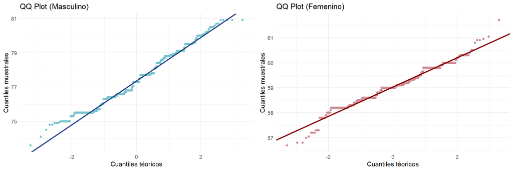

Se puede observar, sobre todo en el caso masculino, que las observaciones parecieran seguir un supuesto de normalidad, con un poco de ruido en aquellos casos donde el estimador de la mediana se encuentre o muy por encima o muy por debajo del promedio de los estimadores. Este fenómeno, en cambio, se aprecia en mayor medida en el gráfico del género femenino. Por lo que podemos asumir normalidad, y proseguir con el cálculo de los intervalos.

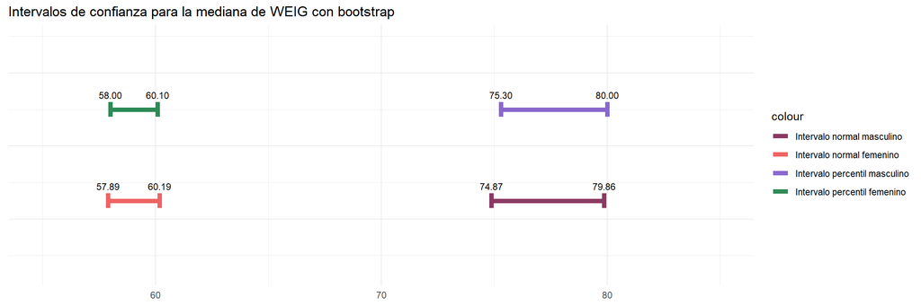

Prosiguiendo, nos interesa ahora observar la relación entre el peso y la altura de las personas, pero teniendo en cuenta las observaciones hechas anteriormente (que el peso varía según el género). Esta relación la veremos desagregada por género.

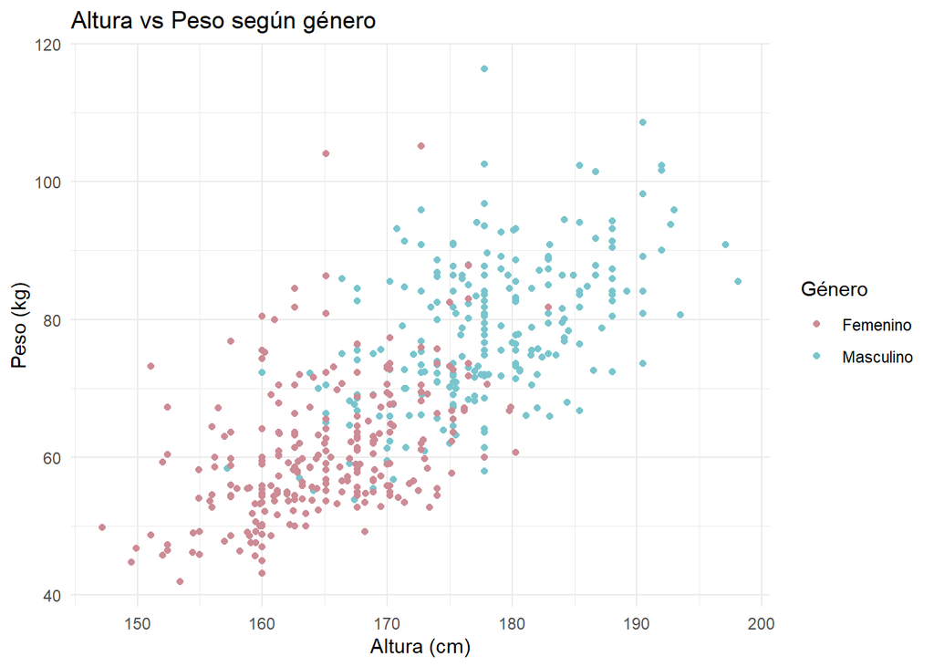

Estudiando el gráfico, en general se observa una correlación positiva entre las variables WEIG y HEIG, indistintamente del género. Ahora, discriminando según el género, claramente se nota una tendencia a poseer tanto pesos como alturas mayores en el género masculino. Si queremos realizar modelos que ajusten o traten de encontrar parámetros que expliquen esta relación, el gráfico nos sugiere que podría ser de utilidad separar nuestras observaciones en género masculino y género femenino.

Ya establecido que el estudio de la relación entre el peso y la altura dependerá del sexo del individuo, estudiemos entonces cada género por separado. Trataremos de ajustar un modelo mediante el estimador de Nadaraya-Watson, con una ventana fija de 10 cm. Este modelo nos dará, para cada altura, una estimación del peso que tendrá cada individuo, mediante un promedio ponderado de las observaciones que se encuentran dentro de esta ventana.

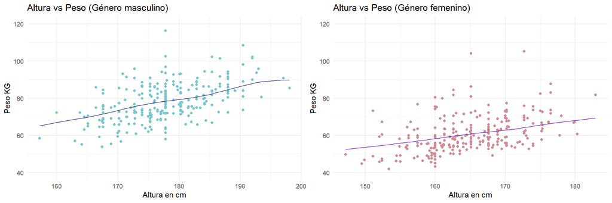

Analicemos ambos gráficos con sus estimadores, que pueden adoptar cualquier forma. Se nota, sobre todo para el género femenino, que el estimador resulta aproximadamente una recta, efecto que se observa en menor medida en la contra-parte masculina. Por otro lado, comparando los estimadores en sí, y no las observaciones, se puede apreciar una mayor inclinación (en general) en el de los hombres que en el de las mujeres. Podríamos plantear que el peso en los hombres es más sensible a la altura, pero esta apreciación no deja de ser mínima, y sería importante comprobarla realizando modelos lineales, relacionando HEIG y WEIG, para ambos géneros.

Por otro lado estos gráficos no dejan de reflejar las observaciones. En vez de realizar un estimador con una ventana arbitraria que podría no ser la óptima, en este caso 10 cm, elegiremos la que si lo es mediante el proceso de convalidación cruzada. Esta ventana será la que minimice la diferencia entre los predichos por el estimador, y los valores reales para las observaciones.

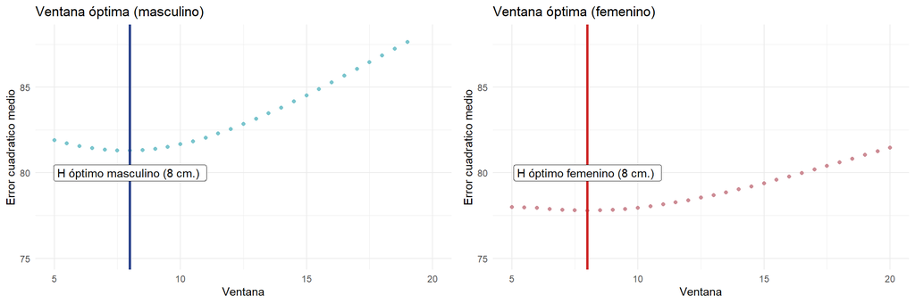

```r
loocv <- function(X,Y,h){
  n.x <- length(X)
  errores <- vector("numeric",n.x)
  for (i in 1:n.x){
    estimacion_i <- ksmooth(X[-i],Y[-i],"normal",h,x.points = X[i])$y
    errores[i] <- (Y[i] - estimacion_i)**2
  }
  return(mean(errores))
}


h_opt_loocv <- function(X,Y,grilla = seq(5,20,0.5)){
  n.h <- length(grilla)
  error_cuadratico <- vector("numeric",n.h)


  for (i in 1:n.h){
    error_cuadratico[i] <- loocv(X,Y,grilla[i])
  }
  datos_aplotear = data.frame("grilla" = grilla, "errores" = error_cuadratico)

  return(list(datos_aplotear = datos_aplotear , h_optimo= grilla[which.min(error_cuadratico)]))
}
```

Vemos que, aunque intuitivamente parezca incorrecto, la ventana óptima para ambos géneros es de 8 cm. Esto nos brinda un error cuadrático medio de 81.3 para el género masculino, y 77.79 para el género femenino.

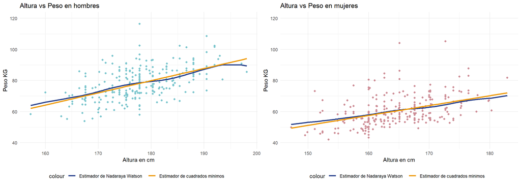

En ambos casos el estimador de Nadaraya-Watson resulta muy parecido a la recta. Como tiene la libertad de tomar cualquier forma, esto nos quiere decir que el estimador ideal se asemeja mucho a una recta. Por ende podemos utilizar el modelo de mínimos cuadrados, ya que es la mejor recta que aproxima los datos, conociendo toda la estructura que tenemos para esto, los coeficientes para las variables y sus interpretaciones, entre otras cosas.

Habiendo graficado y estudiado la recta de cuadrados mínimos, volvamos a la hipótesis que hicimos de Nadaraya-Watson: veamos si en verdad el peso de un hombre es más sensible a la altura con respecto a lo que pasa en el género femenino.

Observamos que el coeficiente que representa la altura para los hombres en la ecuación de la recta de cuadrados mínimos es 0.78, mientras que el de las mujeres es 0.63. Estos coeficientes representan la pendiente de la recta, por lo tanto ahí podemos ver la relación entre lo predicho antes y la conclusión a partir de los coeficientes.

Según los datos, el peso masculino es más sensible a la altura que el femenino, esto confirma lo que habíamos pensado. Esto también nos indica que distinguir por género es adecuado para realizar los modelos.

### Regresión lineal

Ahora pasaremos a la etapa de generar distintos modelos que expliquen la variable de peso, a través del uso de las demás variables presentes en el dataset.

En primer lugar, para tratar de explicar a la variable WEIG, utilizaremos un modelo lineal el cual tendrá a todas las variables restantes como variables explicativas.

Vemos que este modelo posee como coeficientes a

|  | Valor del coeficiente |
| --- | --- |
| (Intercept) | -121.1577026 |
| BIAC | 0.0088893 |
| BIIL | 0.1323768 |
| BITRO | -0.1427294 |
| CHEST1 | 0.3387335 |
| CHEST2 | 0.1222593 |
| ELBOW | 0.0232617 |
| WRIST | 0.2596701 |
| KNEE | 0.4608821 |
| ANKLE | 0.0981439 |
| SHOUL | 0.0769376 |
| CHESTG | 0.1518424 |
| WAISTG | 0.3635750 |
| NAVEL | -0.0297324 |
| HIP | 0.2588315 |
| GLUTE | 0.2141526 |
| BICEP | 0.0489846 |
| FOREA | 0.6032672 |
| KNEEG | 0.2164632 |
| CALF | 0.3712369 |
| ANKLEG | 0.0187119 |
| WRISTG | -0.3175542 |
| AGE | -0.0556990 |
| HEIG | 0.3005362 |
| GENMale | -1.5361134 |

Ahora pasaremos a evaluar la significación de cada coeficiente, es decir, cuán seguros estamos de que sea distinto a 0, pues estamos testeando para cada coeficiente $\beta_i$ la hipótesis $H_0: \beta_i = 0 \quad vs. \quad H_1: \beta_i \neq 0$. Observemos para eso sus p-valores, los que nos indicarán la probabilidad de obtener evidencia en contra de la hipótesis nula ($H_0$) bajo el supuesto de que ésta sea cierta. Entonces, dependiendo de la tolerancia al error que busquemos aceptar, dejaremos en el modelo a cada coeficiente o no.

|  | P-valor |
| --- | --- |
| (Intercept) | 0.0000000 |
| BIAC | 0.9082815 |
| BIIL | 0.0693042 |
| BITRO | 0.1641896 |
| CHEST1 | 0.0000145 |
| CHEST2 | 0.1880703 |
| ELBOW | 0.9144790 |
| WRIST | 0.3005254 |
| KNEE | 0.0032269 |
| ANKLE | 0.5882791 |
| SHOUL | 0.0302306 |
| CHESTG | 0.0006936 |
| WAISTG | 0.0000000 |
| NAVEL | 0.2870005 |
| HIP | 0.0000014 |
| GLUTE | 0.0003573 |
| BICEP | 0.5939042 |
| FOREA | 0.0001280 |
| KNEEG | 0.0152518 |
| CALF | 0.0000018 |
| ANKLEG | 0.8675193 |
| WRISTG | 0.1818151 |
| AGE | 0.0001339 |
| HEIG | 0.0000000 |
| GENMale | 0.0089477 |

Vemos que hay p-valores que dan exactamente 0, pero esto es únicamente porque R no puede imprimir valores tan cercanos al 0. Por ejemplo, el caso de intercept, cuyo p-valor da en el orden de $10^{-140}$, o el caso de HEIG, que da en el orden de $10^{-39}$.

Una vez aclarado esto, nosotros proseguiríamos a quedarnos con aquellas variables que tengan un p-valor, menor o igual a $0.001 \quad$ o $\quad 0.1 \%$ . Esto puede parecer muy estricto, pero consideramos que al poseer más de 20 variables explicativas, es adecuado para reducir el número lo más que podamos. En este caso son las variables de: Intercept, CHEST1, CHESTG, WAISTG, HIP,GLUTE, FOREA,CALF,AGE y HEIG.

El valor del estadístico F es de 669.041218, mientras que su p-valor es de $8.297^{-299}$. Estos datos nos indican que la regresión en conjunto es claramente significativa, es decir, los coeficientes son distintos del $\vec{0}$.

Esto va en concordancia con lo visto anteriormente de aquellas variables para las cuales tenemos evidencia significativa que son distintas a 0 en el modelo. Si solo una variable posee un p-valor extremadamente pequeño, ya sabemos que esa variable nos aportará información a la hora de explicar en este caso el peso, y por lo tanto una regresión que incluya a esa variable será significativa.

Ahora pasaremos a observar la presencia de multicolinealidad en el ajuste propuesto. Lo haremos gráficamente viendo un heatmap, con los valores de la matriz de correlación lineal entre todas las variables explicativas.

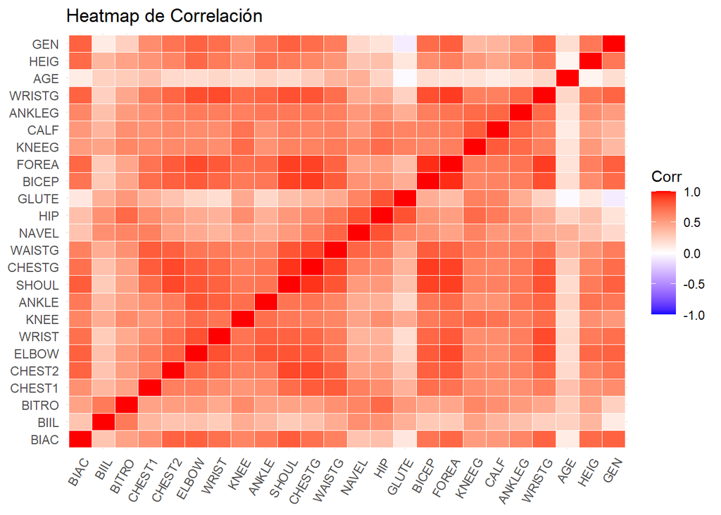

Vemos que existen variables muy correlacionadas linealmente entre sí, como WRISTG con ELBOW o WRIST o SHOUL con CHEST2 o CHESTG (lo cual intuitivamente, regresando a la explicación de cada característica, tiene sentido), lo que puede causar errores numéricos a la hora de estimar coeficientes. Estos errores pueden afectar la significancia que posee un coeficiente, la varianza de los mismos, el desvío estándar de cada estimación, o mismo en sí el valor que adopta el coeficiente. Esto es así, porque en los cálculos se utiliza la matriz que queda mal condicionada, y esto afecta en los valores númericos.

Es por esto, que en el caso de querer generar otro modelo sin todas las variables, hay que tener en cuenta el fenómeno de multicolinealidad, para evitar caer en matrices mal condicionadas que generen errores numéricos propios del cálculo, que pueden agrandar valores, sin que estos sean grandes de por sí.

Por último, veamos el error de predicción del modelo, utilizando los datos separados específicamente para el testeo del mismo.

El error cuadrático medio de predicción del modelo es de 4.2253557, lo cual consideramos un error pequeño, pues en el caso de los hombres, considerando su mediana, es un error del tan solo $5 \%$, mientras que para el género femenino el error sube, y es del $7 \%$.

Ahora pasaremos a considerar un modelo con menos variables, pero primero veremos cuáles elegimos. Para eso tendremos dos criterios, basándonos en lo visto con el modelo lineal que posee todas las variables. Elegiremos aquellas variables con un p-valor menor a $0.001$, aunque esto pueda parecer un poco estricto, y luego de haber realizado esta selección, revisaremos cuáles de ellas generan problemas de colinealidad, para elegir un subconjunto que no tenga una gran multicolinealidad.

Como expresamos anteriormente, utilizando el criterio de la significancia de las variables en el modelo inicial, nos quedaríamos con: Intercept, CHEST1, CHESTG, WAISTG, HIP,GLUTE, FOREA,CALF,AGE y HEIG.

Ahora observaremos un heatmap, para revisar la colinealidad entre este grupo de variables.

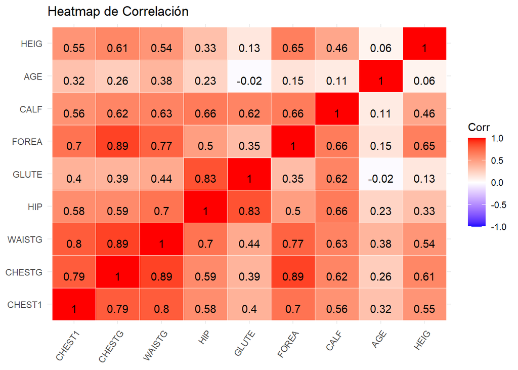

Apreciando el gráfico, vemos que CHESTG tiene mucha correlación (alrededor o superior al $80 \%$) con otras variables, tales como WAISTG, CHEST1 y FOREA por lo que decidimos sacarla y dejar las otras variables. La mayor correlación pasaría a estar entre las variables de GLUTE y HIP, pero al ser únicamente entre estas dos, nos inclinamos a dejarlas en el modelo. Igualmente para corroborar veamos como queda la matriz de correlación sin CHESTG, mediante un heatmap.

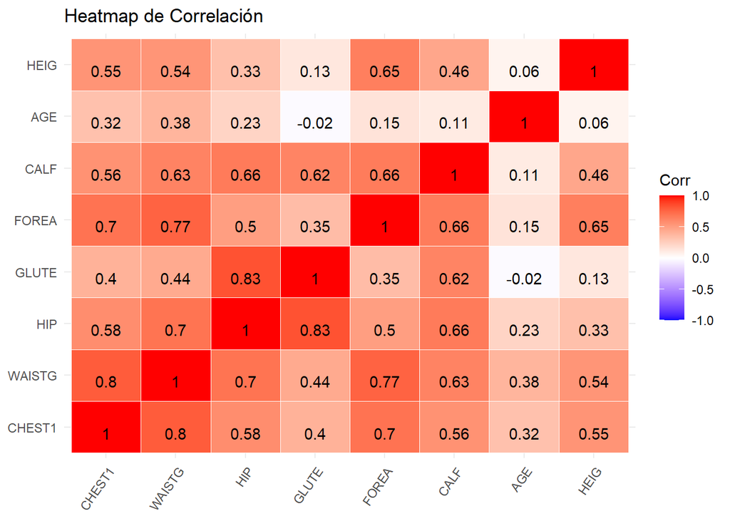

Vemos que queda la matriz de correlación exactamente igual a la anterior, sin la fila ni columna perteneciente a la variable CHESTG.

Por lo que finalmente nos inclinamos a tomar el modelo con las variables : CHEST1, WAISTG, HIP , GLUTE, FOREA , CALF, AGE y HEIG, agregando también el término del intercept.

Vemos que el modelo ajustado presenta los siguientes coeficientes :

|  | Valor del coeficiente |
| --- | --- |
| (Intercept) | -115.2838521 |
| CHEST1 | 0.3706342 |
| WAISTG | 0.4278084 |
| HIP | 0.2954519 |
| GLUTE | 0.2712072 |
| FOREA | 1.0541920 |
| CALF | 0.5041709 |
| AGE | -0.0556709 |
| HEIG | 0.3305170 |

Notamos que el valor del intercept sigue siendo el de mayor valor absoluto, aunque redujo un poco su modulo sigue manteniendo el signo negativo. También cabe destacar que FOREA es el único que aumenta de manera significativa, pues en este modelo contribuye casi el doble a la hora de estimar el peso de la observación. En cuanto al resto de los coeficientes, vemos que variaron poco respecto del modelo con todas las variables.

Proseguiremos observando la significancia de las variables en el modelo, observando los p-valores de las mismas. Nuestra hipótesis es que todas las variables siguen siendo muy significativas (pues así las elegimos).

|  | P-valor |
| --- | --- |
| (Intercept) | 0.0000000 |
| CHEST1 | 0.0000043 |
| WAISTG | 0.0000000 |
| HIP | 0.0000000 |
| GLUTE | 0.0000021 |
| FOREA | 0.0000000 |
| CALF | 0.0000000 |
| AGE | 0.0001534 |
| HEIG | 0.0000000 |

Queda claro que la hipótesis es cierta, y vemos evidencia significativa de que todos los coeficientes del modelo son distintos a 0 y aportan a la hora de predecir o estimar el peso de una persona.

Por otro lado, podemos comparar los modelos estudiando lo que llamamos adjusted R squared: representa la proporción de variabilidad de la variable $Y$ que es explicada por el modelo propuesto, relativa a cuanta variabilidad tiene $Y$ respecto de su media (es decir, a ser explicada sin aplicar el modelo). Utilizamos el adjusted R squared y no el R squared normal, pues este último no es sensible a la cantidad de parámetros de los modelos, y no sería una comparación justa.

En el modelo con todas las variables, este coeficiente es de 0.976, mientras que en el modelo con las variables seleccionadas, el valor es de 0.971 .

Podemos notar una diferencia mínima en esta métrica, a favor del modelo que posee todas las variables. Esto que nos indica que agregar las variables nos permite una ínfima mejoría a la hora de explicar la variabilidad del peso mediante el modelo, en relación a cuanta variabilidad posee WEIG de por sí.

También podemos observar la varianza residual de los modelos. Esta métrica nos dice cuanta varianza poseen los errores según el modelo. En este caso buscaremos que este número sea menor, pues nos indicaría que los errores poseen una menor variación. En el modelo con el conjunto de variables seleccionadas, este valor es de 5.401, mientras que en el modelo con todas, el coeficiente resulto 4.513.

Igual a lo visto en el caso del adjusted R squared, notamos que el modelo con todas las variables posee una leve ventaja en la métrica, con una diferencia en este caso del $20 \%$. Intuitivamente, esto es razonable, pues el modelo con menos variables, es menos sensible a los pequeños cambios que puedan generar variables no elegidas para el mismo, haciendo que el error posea una mayor varianza.

Finalmente, observemos el error cuadrático medio de predicción del modelo: 5.194. Este valor es un poco mayor a lo visto para el modelo con todas las variables.

En conclusión, vimos que en todas las métricas observadas el modelo elegido da un poco peor con respecto al modelo con todas las variables y esto puede deberse a varios motivos. Puede ser propio de la variable a explicar peso, y su relación con casi todas las variables explicativas presentes en el dataset, lo cual genera que todas presenten aunque sea una mínima relevancia a la hora de explicarla. Se puede deber también a las decisiones tomadas a la hora de generar el modelo, como la selección estricta de variables cuando tratamos la significancia, o la decisión de sacar la variable CHESTG y no otras a la hora de evitar la multicolinealidad.

Prosiguiendo, veremos las herramientas teóricas para realizar lo que hicimos anteriormente de manera manual, es decir, trataremos de realizar nuevos modelos con menos variables, buscando mantener errores de predicción similares. Para esto utilizaremos el método LASSO en el cual se penaliza a la estimación de los coeficientes cuando toman valores grandes. El método está dado mediante la siguiente fórmula:

$$\hat{\beta}^{\text{LASSO}} = \text{arg
min}_b \left\{ \frac{1}{2n} \sum{i=1}^n [y_i - x_i^t b]^2 + \lambda
\sum_{j=1}^p |b_j| \right\}$$

para $\lambda > 0$

La primer sumatoria penaliza el mal ajuste del modelo, mientras que la segunda penaliza los coeficientes no nulos. Esta penalización se puede controlar mediante la elección de $\lambda$.

Veamos en primer lugar como varían los coeficientes elegidos según el $\lambda$ utilizado.

Tomando 5 valores de $\lambda$ distintos, los coeficientes resultaron:

|  | 12.1071934187882 | 2.06712487370077 | 0.321577685254158 | 0.0500270733370276 | 0.00854138561071844 |
| --- | --- | --- | --- | --- | --- |
| (Intercept) | 69.37143 | -72.1593691 | -113.7635754 | -118.6984578 | -121.8755029 |
| BIAC | 0.00000 | 0.0000000 | 0.0000000 | 0.0000000 | 0.0000000 |
| BIIL | 0.00000 | 0.0000000 | 0.0011430 | 0.1014816 | 0.1242402 |
| BITRO | 0.00000 | 0.0000000 | 0.0000000 | 0.0000000 | -0.1019481 |
| CHEST1 | 0.00000 | 0.0280838 | 0.2227271 | 0.2975019 | 0.3277323 |
| CHEST2 | 0.00000 | 0.0000000 | 0.0655739 | 0.0944773 | 0.1217277 |
| ELBOW | 0.00000 | 0.0000000 | 0.0000000 | 0.0000000 | 0.0000669 |
| WRIST | 0.00000 | 0.0000000 | 0.0000000 | 0.1342803 | 0.2248165 |
| KNEE | 0.00000 | 0.0664442 | 0.3369937 | 0.3968800 | 0.4458599 |
| ANKLE | 0.00000 | 0.0000000 | 0.0000000 | 0.0000000 | 0.0767784 |
| SHOUL | 0.00000 | 0.0610247 | 0.0713136 | 0.0716500 | 0.0791691 |
| CHESTG | 0.00000 | 0.2321843 | 0.1841699 | 0.1740699 | 0.1546467 |
| WAISTG | 0.00000 | 0.2710570 | 0.2971487 | 0.3246144 | 0.3520331 |
| NAVEL | 0.00000 | 0.0000000 | 0.0000000 | 0.0000000 | -0.0129192 |
| HIP | 0.00000 | 0.2473637 | 0.2453020 | 0.2340480 | 0.2428347 |
| GLUTE | 0.00000 | 0.0000000 | 0.2492497 | 0.2668748 | 0.2322389 |
| BICEP | 0.00000 | 0.0000000 | 0.0000000 | 0.0012729 | 0.0315511 |
| FOREA | 0.00000 | 0.4647625 | 0.5140644 | 0.4801412 | 0.5619799 |
| KNEEG | 0.00000 | 0.4240253 | 0.2652437 | 0.2283960 | 0.2143610 |
| CALF | 0.00000 | 0.3126872 | 0.3758102 | 0.3712822 | 0.3735256 |
| ANKLEG | 0.00000 | 0.0000000 | 0.0000000 | 0.0000000 | 0.0000000 |
| WRISTG | 0.00000 | 0.0000000 | 0.0000000 | 0.0000000 | -0.1753507 |
| AGE | 0.00000 | 0.0000000 | -0.0014951 | -0.0514842 | -0.0570127 |
| HEIG | 0.00000 | 0.1626988 | 0.2824733 | 0.2824937 | 0.2967601 |
| GENFemale | 0.00000 | 0.0000000 | 0.0000000 | 0.1137196 | 1.1754562 |
| GENMale | 0.00000 | 0.0000000 | 0.0000000 | 0.0000000 | 0.0000000 |

Claramente podemos notar que a mayor valor de $\lambda$, más coeficientes son nulos. Esto puede deberse a que se penaliza de mayor manera la presencia de coeficientes no nulos, y por lo tanto los valores óptimos que minimizan esa función objetivo, no poseen muchos coeficientes no nulos.

Gráficamente, podemos ver en la siguiente figura como varían los valores de los coeficientes, según el valor de $\lambda$. Este último valor lo veremos en función de su logaritmo, para apreciar mejor la diferencia entre valores cercanos al 0, pero que poseen distintos órdenes de magnitud.

[interactive chart not shown]

Como dijimos, podemos observar que a medida que aumenta el $\lambda$ también aumenta la cantidad de variables que pasan a valer a 0 (con el deslizador podemos ir avanzando sobre los valores para ver como la variables pasan a valer 0 de forma continua). Además podemos apreciar que en el gráfico no aparece la variable de intercept. Esto es porque posee valores que difieren en el orden de magnitud del resto de los coeficientes. Si la graficáramos, no se podría apreciar el resto de variables.

Los coeficientes que se mantienen no nulos a medida que el valor del $\log\lambda$ aumenta son SHOUL, WAISTG, CHESTG, FOREA y KNEEG

Pensemos cuál es el valor óptimo para el parámetro de penalización $\lambda$. Para eso volveremos a usar el método de Cross-Validation, donde todas las observaciones presentes en el dataset de entrenamiento juegan el papel, a veces de entrenamiento, y otras veces de testeo. A partir de una grilla de valores de $\lambda$, nos quedaremos con el valor que genere menor error, al que llamaremos $\lambda_{min}$. Para la generación del modelo de predicción utilizaremos el valor $\lambda_{1se}$, que es el mayor valor de $\lambda$ que posee un error con valor a menor de un desvío estándar del error del $\lambda_{min}$.

En primer lugar, veamos los valores de los errores en función del logaritmo del $\lambda$ elegido. Notar que en el eje horizontal en la parte superior se nos indican aquellos parámetros distintos de 0.

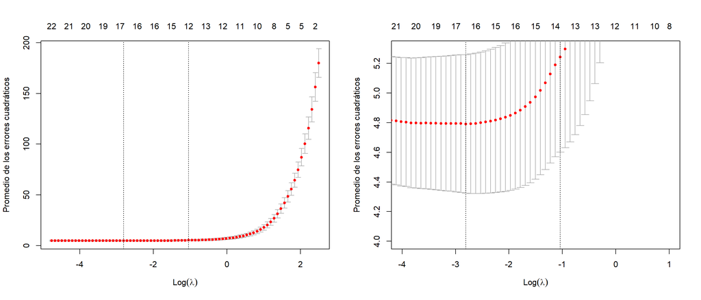

Las líneas punteadas marcan el valor de los logaritmos de $\lambda_{min}$, la de menor valor, y $\lambda_{1se}$, la de mayor valor. Los “bigotes” en cada $\lambda$ marcan un desvío estándar de su error hacia arriba y hacia abajo.

Analicemos ambos gráficos: el gráfico de la izquiera es el gráfico general y el de la derecha es la versión ampliada en el lugar donde nos interesa observar el comportamiento. La secuencia de errores cuadráticos sube notoriamente una vez que el logaritmo pasa el orden de magnitud $-1$. Pasando al gráfico ampliado, vemos claramente que el valor de $\lambda_{1se}$ es el mayor dentro de los que poseen un error cuadrático medio a un desvío estándar del generado por $\lambda_{min}$ .

El modelo ajustado para $\lambda_{1se}$, con un valor de 0.3529311 , posee los coeficientes:

|  | Valor del coeficiente |
| --- | --- |
| (Intercept) | -113.0625756 |
| BIAC | 0.0000000 |
| BIIL | 0.0000000 |
| BITRO | 0.0000000 |
| CHEST1 | 0.2170127 |
| CHEST2 | 0.0603532 |
| ELBOW | 0.0000000 |
| WRIST | 0.0000000 |
| KNEE | 0.3292489 |
| ANKLE | 0.0000000 |
| SHOUL | 0.0712580 |
| CHESTG | 0.1858613 |
| WAISTG | 0.2956906 |
| NAVEL | 0.0000000 |
| HIP | 0.2475775 |
| GLUTE | 0.2418645 |
| BICEP | 0.0000000 |
| FOREA | 0.5149740 |
| KNEEG | 0.2687182 |
| CALF | 0.3768195 |
| ANKLEG | 0.0000000 |
| WRISTG | 0.0000000 |
| AGE | 0.0000000 |
| HEIG | 0.2805018 |
| GENFemale | 0.0000000 |
| GENMale | 0.0000000 |

Comparemos con el modelo lineal de todas las variables, y con el modelo donde seleccionamos mediante criterios arbitrarios ciertas variables. En primer lugar, veamos los valores de los coeficientes.

|  | Todas las variables | Variables seleccionadas | Modelo LASSO |
| --- | --- | --- | --- |
| (Intercept) | -121.1577026 | -115.2838521 | -113.0625756 |
| BIAC | 0.0088893 | 0.0000000 | 0.0000000 |
| BIIL | 0.1323768 | 0.0000000 | 0.0000000 |
| BITRO | -0.1427294 | 0.0000000 | 0.0000000 |
| CHEST1 | 0.3387335 | 0.3706342 | 0.2170127 |
| CHEST2 | 0.1222593 | 0.0000000 | 0.0603532 |
| ELBOW | 0.0232617 | 0.0000000 | 0.0000000 |
| WRIST | 0.2596701 | 0.0000000 | 0.0000000 |
| KNEE | 0.4608821 | 0.0000000 | 0.3292489 |
| ANKLE | 0.0981439 | 0.0000000 | 0.0000000 |
| SHOUL | 0.0769376 | 0.0000000 | 0.0712580 |
| CHESTG | 0.1518424 | 0.0000000 | 0.1858613 |
| WAISTG | 0.3635750 | 0.4278084 | 0.2956906 |
| NAVEL | -0.0297324 | 0.0000000 | 0.0000000 |
| HIP | 0.2588315 | 0.2954519 | 0.2475775 |
| GLUTE | 0.2141526 | 0.2712072 | 0.2418645 |
| BICEP | 0.0489846 | 0.0000000 | 0.0000000 |
| FOREA | 0.6032672 | 1.0541920 | 0.5149740 |
| KNEEG | 0.2164632 | 0.0000000 | 0.2687182 |
| CALF | 0.3712369 | 0.5041709 | 0.3768195 |
| ANKLEG | 0.0187119 | 0.0000000 | 0.0000000 |
| WRISTG | -0.3175542 | 0.0000000 | 0.0000000 |
| AGE | -0.0556990 | -0.0556709 | 0.0000000 |
| HEIG | 0.3005362 | 0.3305170 | 0.2805018 |
| GENMale | -1.5361134 | 0.0000000 | 0.0000000 |
| GENFemale | 0.0000000 | 0.0000000 | 0.0000000 |

Comparemos las variables con coeficientes nulos en nuestros modelos y en el modelo de LASSO. En particular este último no llevo a cero los coeficientes de: CHEST2, KNEE,SHOUL,CHESTG y KNEEG, que nosostros sí en nuestro modelo. Salvo CHESTG, todas fueron eliminadas por falta de significancia. Si volvemos a ver los p-valores, vemos que únicamente KNEE podría haber sido elegida, si buscamos errores menores al $1 \%$. CHESTG fue eliminada de nuestro modelo en búsqueda de no causar multicolinealidad.

En nuestro modelo elegimos AGE a la hora de explicar el peso, mientras que LASSO, lo dejo como coeficiente nulo.

Finalmente veamos los errores de predicción de los tres modelos, mediante el uso de las observaciones separadas para el testeo.

Para el modelo con todas las variables recordemos que el error cuadrático medio de predicción fue de 4.225, el del modelo con variables seleccionadas arbitrariamente fue de 5.194, y finalmente el error del modelo de LASSO dio un valor de 4.318.

Claramente vemos que el mejor modelo, de acuerdo al error, resulta el que posee todas las variables, pero también observamos que hay una diferencia menor a $0.1$ con el modelo que nos brinda LASSO. En la práctica este modelo puede ser utilizado tranquilamente, ya que posee la ventaja de no tener todas las variables del dataset como explicativas y, además, el error posee únicamente un $2 \%$ de diferencia del modelo que tiene el mejor ajuste de todos, obtenido por mínimos cuadrados.

También notemos que el modelo elegido arbitrariamente resultó peor que los otros dos modelos, para el cual nos apoyamos únicamente en herramientas teóricas, en la métrica del error cuadrático medio, y en las métricas de varianza residual y adjusted R squared en comparación al modelo que posee todas las variables.

##### Conclusión final

Comenzamos este estudio observando la distribución del WEIG según el género de las personas, de donde arribamos a la conclusión de que dependía totalmente del género. Esto es así pues vimos que para los hombres, los estimadores e intervalos buscados eran mayores a los buscados para las mujeres.

Luego observamos en detalle como variaba la distribución del peso según la variable altura, también desagregando por género. De esto arribamos a que a mayor altura, mayor peso, por lo que pensamos que la variable HEIG era fundamental a la hora de explicar el WEIG. También notamos que esta relación variaba dependiendo el género de las personas.

Posteriormente llegó el momento de realizar los modelos explicativos para la variable WEIG. Allí realizamos tres ajustes distintos, con diferentes técnicas. En primer lugar utilizamos cuadrados mínimos con todas las variables presentes en el dataset. Esto nos brindó un modelo complejo, pero que a posteriori resultó ser el mejor en todas las métricas observadas. Luego mediante criterios arbitrarios elegimos distintas variables, generando un modelo, también lineal, con menos coeficientes, un poco más simple. Lamentablemente luego vimos que de los tres probados, tenía el mayor error de predicción, lo que probablemente nos diga que fuimos un poco estrictos en los criterios utilizados. Por último, mediante la regresión LASSO, obtuvimos otro modelo, también con coeficientes nulos, pero no tantos como los obtenidos anteriormente. Este modelo posee un error cuadrático medio de predicción similar al mejor (el de todas las variables).

Veamos ahora el comportamiento de los modelos finales. El modelo con todas las observaciones tiene un error de predicción de 4.2372553, el modelo arbitrario tiene un error de 5.2670035, y por último el modelo de LASSO tiene un error cuadrático medio de predicción de 4.7438411. Notamos que se mantienen los comportamientos previamente descritos, pero que aquí, con todas las observaciones, aumenta la diferencia en el error entre el modelo provisto con LASSO, y el modelo que utiliza todas las variables.

Por lo explicado previamente, en caso de tener que elegir un único modelo, nos quedaríamos con el modelo dado por LASSO, pues si bien no es el modelo que menores errores produce, se acerca a estos, y posee la ventaja de tener aproximadamente la mitad de variables en el dataset con coeficientes nulos. Pasemos entonces a estudiar este modelo y sus coeficientes.

El modelo posee un valor de intercept de aproximadamente $-113$, y el resto de coeficientes son todos positivos, pero cercanos a 0, por lo cual, la suma de estos compensará el coeficiente de intercept y aumentará hasta llegar al peso estimado para cada observación. En caso contrario a lo visto al comienzo del estudio, donde notamos que tanto el género como la altura son importantes a la hora de explicar el peso, vemos que los coeficientes asignados son de $0.28$ para el caso de la altura, y $0$ para ambos géneros. Esto último, podría deberse a que las variables presentes en la explicación también varían de acuerdo al género, como son CHEST,HIP o GLUTE. En cuanto al coeficiente de la altura, vemos que es uno de los mayores, por lo cual lo visto en la etapa exploratoria se confirmó: la altura es importante a la hora de determinar una buena estimación para el peso de las personas.

Nos llevamos la sorpresa de ver que el coeficiente de mayor valor (obviando el intercept) es el de FOREA, el cual recordemos, habla de la circunferencia del antebrazo, extendido, palma hacia arriba (promedio de circunferencias derecha e izquierda). A priori no parecería ser indicador del peso de una persona, pero vemos que nuestro modelo de LASSO (y en los otros modelos estudiados), es tomado como el más importante a la hora de realizar predicciones sobre el peso de las personas.

En conclusión, nuestro estudio se basó en realizar una exploración de datos. Primero trabajamos solo en la variable WEIG, que terminó siendo nuestra variable de estudio, desagregando por género. Luego agregamos al estudio otra variable que intuitivamente poseía mucho sentido, la altura. Posteriormente realizamos distintos modelos lineales explicativos, buscando estudiar a la variable de WEIG. Uno de ellos fue con todas las variables, el cual resultó ser el mejor de los tres. El segundo se planteó seleccionando un conjunto de variables, mediante distintos criterios arbitrarios. El último modelo se desarrolló utilizando herramientas teóricas, la regresión de LASSO. Habiendo estudiado y comparado los tres modelos, concluimos que el modelo de LASSO genera un mejor ajuste que el logrado eligiendo variables por criterios arbitrarios; y que lo elegimos también por sobre el de todas las variables ya que resulta más simple y el error no se aleja mucho.